# Analyse_ab_test_results_slides slides

## Analyse A/B Test Results

by Anas A. Mohaisin

- Introduction
- Part I - Probability
- Part II - A/B Test
- Part III - Regression

### Introduction

For this project, you will be working to understand the results of an A/B test run by an e-commerce website. Your goal is to work through this notebook to help the company understand if they should implement the new page, keep the old page, or perhaps run the experiment longer to make their decision.

#### Part I - Probability

```python
df.query("(group == 'treatment' and landing_page == 'old_page') | (group == 'control' and landing_page == 'new_page')")
```

|  | user_id | timestamp | group | landing_page | converted |
| --- | --- | --- | --- | --- | --- |
| 22 | 767017 | 2017-01-12 22:58:14.991443 | control | new_page | 0 |
| 240 | 733976 | 2017-01-11 15:11:16.407599 | control | new_page | 0 |
| 308 | 857184 | 2017-01-20 07:34:59.832626 | treatment | old_page | 0 |
| 327 | 686623 | 2017-01-09 14:26:40.734775 | treatment | old_page | 0 |
| 357 | 856078 | 2017-01-12 12:29:30.354835 | treatment | old_page | 0 |
| ... | ... | ... | ... | ... | ... |
| 294014 | 813406 | 2017-01-09 06:25:33.223301 | treatment | old_page | 0 |
| 294200 | 928506 | 2017-01-13 21:32:10.491309 | control | new_page | 0 |
| 294252 | 892498 | 2017-01-22 01:11:10.463211 | treatment | old_page | 0 |
| 294253 | 886135 | 2017-01-06 12:49:20.509403 | control | new_page | 0 |
| 294331 | 689637 | 2017-01-13 11:34:28.339532 | control | new_page | 0 |

3893 rows × 5 columns

There are 290584 unique users

Index 1899 and 2893 show that user ID 773192 is repeated twice.

Repeatd user ID 773192 belongs to the treatment group who landed new page and is non-converted.

The probability for being converted is 11.95%; i.e. $P(converted = True)=0.1195$

The probability for being converted given an individual belongs to the control group is 12%;\ i.e. $P(converted = True|control group)=0.12$

The probability for being belonging to the treatment group given converted is 11.88%;\ i.e. $P(converted=True|treatment group)=0.1188$

The probability for being converted given that the individual belong to the treated or controlled groups, shows no difference (very slight difference) 11.8% and 12%, respectively. On the other hand, the probability for individual who receives a new page is 50% which means that the probability to receive an old page is 50% too $P(\neg New page)=(New page)=0.5$ Therefore, there is no sufficient evidence that the treatment leads to more conversions.

### Part II - A/B Test

$H_0: p_{new} \leq p_{old}\\ H_a: p_{new} > p_{old}$ 1. Null Hypothsis: New page is similar or less then old page. 2. Alternate Hypothsis: New page is better than the old page.

converted rate is 11.9 for the new page

converted rate is 11.9 for the old page.

Number of users who land the new page is 145310

Simulate a uniform random sample, size = 145310 , $P(0.119,(1-0.119) = 0.881$

Simulate a uniform random sample, size = 145274 , $P(0.119,(1-0.119) = 0.88$

The difference between observed simulated mean is 0

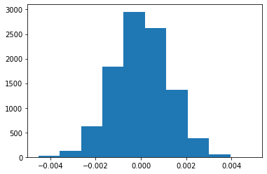

```python
plt.hist(p_diffs);
```

```
0.9056
```

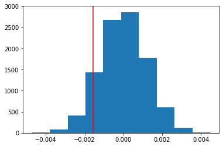

```python
p_diffs = np.array(p_diffs)
obs_diff=df2.query('group=="treatment"')['converted'].mean()-df2.query('group=="control"')['converted'].mean()
null_val=np.random.normal(0,p_diffs.std(),p_diffs.size)

plt.hist(null_val)
plt.axvline(x=obs_diff,color='r'); (null_val>obs_diff).mean()
```

1.We have drawn a sample for guassian distibution where $ \sim \mathcal{N}(0,\sigma^2)$ to find the p-value.\ 2. It is the p-value. It is the statistical sigfinicance level which represents the rejection area $\alpha$ where accept the $H_0$ if the P-value $> \alpha$ or fail to accept the $H_0$ if P-value $< \alpha$.\ 3. Clearly, we accept the $H_0$ at statistical sigificance level $\alpha=0.05$

In z-score we bring our data around the mean value. So, we agree with **j.** and **k.** as P-value in ~ 0.90 where we accept the $H_0$

### Part III - A regression approach

It is a **logistic regression model** where: $ y_i= \begin{cases} 1, &\text{if } {y_i}^\ast \geq 0\\ 0, &\text{if } {y_i}^\ast <0\\ \end{cases} $

```python
df2[['new_page','old_page']]=pd.get_dummies(df2['landing_page'])
df2[['treatement','ab_page',]]=pd.get_dummies(df2['group'])
df2['intercept']=1
df2.head()
```

|  | user_id | timestamp | group | landing_page | converted | new_page | old_page | treatement | ab_page | intercept |
| --- | --- | --- | --- | --- | --- | --- | --- | --- | --- | --- |
| 0 | 851104 | 2017-01-21 22:11:48.556739 | control | old_page | 0 | 0 | 1 | 1 | 0 | 1 |
| 1 | 804228 | 2017-01-12 08:01:45.159739 | control | old_page | 0 | 0 | 1 | 1 | 0 | 1 |
| 2 | 661590 | 2017-01-11 16:55:06.154213 | treatment | new_page | 0 | 1 | 0 | 0 | 1 | 1 |
| 3 | 853541 | 2017-01-08 18:28:03.143765 | treatment | new_page | 0 | 1 | 0 | 0 | 1 | 1 |
| 4 | 864975 | 2017-01-21 01:52:26.210827 | control | old_page | 1 | 0 | 1 | 1 | 0 | 1 |

```python
logit_m.summary()
```

Logit Regression Results

| Dep. Variable: | converted | No. Observations: | 290584 |
| --- | --- | --- | --- |
| Model: | Logit | Df Residuals: | 290582 |
| Method: | MLE | Df Model: | 1 |
| Date: | Thu, 12 Nov 2020 | Pseudo R-squ.: | 8.077e-06 |
| Time: | 16:07:49 | Log-Likelihood: | -1.0639e+05 |
| converged: | True | LL-Null: | -1.0639e+05 |
| Covariance Type: | nonrobust | LLR p-value: | 0.1899 |

|  | coef | std err | z | P>\|z\| | [0.025 | 0.975] |
| --- | --- | --- | --- | --- | --- | --- |
| intercept | -1.9888 | 0.008 | -246.669 | 0.000 | -2.005 | -1.973 |
| ab_page | -0.0150 | 0.011 | -1.311 | 0.190 | -0.037 | 0.007 |

Consider other variables is related to model identification which can not be arbitrary. Model can be just-identified, over-identified, or under-indentified. From a mathematical standpoint, if we add one or more variables, we may have high value for $R^2$ but ${\mathbb E}(x_i,\epsilon) \neq 0$, where error term is correlated with Age or Eduction i.e. endogenity. Or measurement error in $x_i$ where the parameters are biased downward. Conversely, if we drop/don't add one or more variable then it is an omitted variable problem where the parameters are biased upward. Therefore, model should be just-identified where parameters are unique.\ E.g. If we add the Education level variable for an individual who may convert or not. The question is: what if an individual's Education Level is affected by mother/father's Eduction level!

```python
df_new[['US','CA','UK']]=pd.get_dummies(df_new['country'])
df_new=df_new.drop('US', axis=1)
#df_new.head()
logit_m=(sm.Logit(df_new['converted'],df_new[['intercept','ab_page','CA','UK']])).fit()
logit_m.summary()
```

```
Optimization terminated successfully.
         Current function value: 0.366113
         Iterations 6
```

Logit Regression Results

| Dep. Variable: | converted | No. Observations: | 290584 |
| --- | --- | --- | --- |
| Model: | Logit | Df Residuals: | 290580 |
| Method: | MLE | Df Model: | 3 |
| Date: | Thu, 12 Nov 2020 | Pseudo R-squ.: | 2.323e-05 |
| Time: | 16:07:51 | Log-Likelihood: | -1.0639e+05 |
| converged: | True | LL-Null: | -1.0639e+05 |
| Covariance Type: | nonrobust | LLR p-value: | 0.1760 |

|  | coef | std err | z | P>\|z\| | [0.025 | 0.975] |
| --- | --- | --- | --- | --- | --- | --- |
| intercept | -2.0300 | 0.027 | -76.249 | 0.000 | -2.082 | -1.978 |
| ab_page | -0.0149 | 0.011 | -1.307 | 0.191 | -0.037 | 0.007 |
| CA | 0.0506 | 0.028 | 1.784 | 0.074 | -0.005 | 0.106 |
| UK | 0.0408 | 0.027 | 1.516 | 0.130 | -0.012 | 0.093 |

```python
np.exp(-0.0149),np.exp(0.0506),np.exp(0.0408)
```

```
(0.9852104557227469, 1.0519020483004984, 1.0416437559600236)
```

```python
### Fit Your Linear Model And Obtain the Results
import statsmodels.formula.api as smf
logit_m=(sm.Logit(df_new['converted'],df_new[['intercept','ab_page','CA','UK','CA_ab_page','UK_ab_page']])).fit()
logit_m.summary()
```

```
Optimization terminated successfully.
         Current function value: 0.366109
         Iterations 6
```

Logit Regression Results

| Dep. Variable: | converted | No. Observations: | 290584 |
| --- | --- | --- | --- |
| Model: | Logit | Df Residuals: | 290578 |
| Method: | MLE | Df Model: | 5 |
| Date: | Thu, 12 Nov 2020 | Pseudo R-squ.: | 3.482e-05 |
| Time: | 16:07:52 | Log-Likelihood: | -1.0639e+05 |
| converged: | True | LL-Null: | -1.0639e+05 |
| Covariance Type: | nonrobust | LLR p-value: | 0.1920 |

|  | coef | std err | z | P>\|z\| | [0.025 | 0.975] |
| --- | --- | --- | --- | --- | --- | --- |
| intercept | -2.0040 | 0.036 | -55.008 | 0.000 | -2.075 | -1.933 |
| ab_page | -0.0674 | 0.052 | -1.297 | 0.195 | -0.169 | 0.034 |
| CA | 0.0118 | 0.040 | 0.296 | 0.767 | -0.066 | 0.090 |
| UK | 0.0175 | 0.038 | 0.465 | 0.642 | -0.056 | 0.091 |
| CA_ab_page | 0.0783 | 0.057 | 1.378 | 0.168 | -0.033 | 0.190 |
| UK_ab_page | 0.0469 | 0.054 | 0.872 | 0.383 | -0.059 | 0.152 |

```python
np.exp(-0.0674),np.exp(0.0118),np.exp(0.0175),np.exp(0.0783),np.exp(0.0469)
```

```
(0.9348211980618836,
 1.011869894648401,
 1.0176540221507617,
 1.0814470441230692,
 1.048017202119183)
```